# IML_Week_4_Assignment_Learner_template

## Objective

This homework sheet will help reviewing the basic concepts associated with classification models. Please review the lectures, suggested readings, and additional resources before getting started on the HW.

**Some questions in this assignment will require you to conduct independent research beyond the material covered in the recorded content.**

**Questions**

This homework is divided into two main parts. First, a conceptual component will review the basic concepts related to classification models. The second part of the homework is mostly intended to be a brief introduction to fitting and analyzing classifiers in `Python`. Several of these questions are modified from James et al. (2021).

Marks Distribution

| Question | Marks |
| --- | --- |
| 1a | 0.25 |
| 1b | 0.25 |
| 1c | 0.25 |
| 1d | 0.25 |
| 2a | 0.50 |
| 2b | 0.50 |
| 3 | 1 |
| 4a | 1 |
| 4b | 1 |
| 4c | 0.5 |
| 4d | 1 |
| 4e | 1 |
| 4f | 1 |
| 4g | 0.25 |
| 4h | 0.25 |
| 5a | 1 |
| 5b | 1 |
| 5c | 1 |
| 5d | 1 |
| 5e | 1 |
| 5f | 1 |

## Conceptual Questions

### Q1. Let’s examine the differences between LDA and QDA.

#### a) If the Bayes decision boundary is linear, do we expect LDA or QDA to perform better on the training set? What about in the test set?

If the Bayes decision boundary is linear, do we expect LDA to perform well in test set. while QDA might perform better in training set. This is because QDA has more flexibilty and will fit the training set more accurately.

#### b) If the Bayes decision boundary is non-linear, do we expect LDA or QDA to perform better on the training set? On the test set?

If the Bayes decision boundary is non-linear, we would expect QDA to perform better on both the training and test sets. QDA can model non-linear decision boundaries more accurately than LDA due to its flexibility in allowing different covariance matrices for each class.

#### c)In general, as the sample size n increases, do we expect the test prediction accuracy of QDA relative to LDA to improve, decline, or be unchanged? Why?

As the sample size n increases, we would expect the test prediction accuracy of QDA relative to LDA to improve. As the sample size n increases, the estimates of the covariance matrices in QDA become more reliable. QDA can then better capture the true underlying covariance structure of the data, leading to improved performance and higher test prediction accuracy relative to LDA.

#### d)True or False:

Even if the Bayes decision boundary for a given problem is linear, we will probably achieve a superior test error rate using QDA rather than LDA because QDA is flexible enough to model a linear decision boundary.

False. If the Bayes decision boundary for a given problem is linear, and the assumptions of LDA hold true (such as a common covariance matrix for all classes), then LDA is expected to achieve a superior test error rate compared to QDA.

### Q2) In relation to the odds and the Default dataset

#### a) On average, what fraction of people with an odds of `0.37` of defaulting on their credit card payment will in fact default?

The probability of an event $E$ with a $O(A)$ occurring is $ \frac{O(A)}{1+O(A)}$ $$ P(A) = = \frac{O(A)}{(1+O(A))} = \frac{0.37}{(1+0.37)} = 0.2700729927 $$ 0.2700729927 of the people will default on their credit card payment given the odds are 0.37

#### b) Suppose that an individual has a `16%` chance of defaulting on their credit card payment. What are the odds that they will default?

The odds of an event $E$ with a probability $P(A)$ occurring is $ \frac{P(A)}{1-P(A)}$ $$ Odds(A) = \frac{P(A)}{(1-P(A))} = \frac{0.16}{(1-0.16)} = 0.19047619047 $$ There the odds that they will default is 0.19048

#### Q3. Suppose that we take a data set, divide it into equally sized training and test sets, and then try out two different classification procedures. First, we use logistic regression and get an error rate of `20%` on the training data and `30%` on the test data. Next we use 1-nearest neighbors (i.e. `K=1`) and get an average error rate (averaged over both test and training data sets) of `18%`. Based on these results, which method should we prefer to use for classification of new observations? Why?

Using K-nearest neighbors (KNN) with K=1 can lead to overfitting and in poor generalization to unseen data. This model may capture noise or outliers present in the training data. This is because for a given point $x_i$ we are looking at DataSet $X$ and see which point is closest. For the training data, it means the prediciton will always will be correct. Hence the training error should be $0\%$. Hence the training error should be $18\% x 2$ which is $ 36\% $. Hence the logistic Regression performs better with 30% error in test data. Therefore **we should prefer logistic regression**

## Applied

#### 4) This question should be answered using the `Weekly` data set, which is part of the `ISLR2` package. This data is similar in nature to the `Smarket` data examined in the book (Ch4, lab). First, load the dataset:

https://book.huihoo.com/introduction-to-statistical-learning/data.html

Link for getting rdataset into python: https://www.statsmodels.org/dev/datasets/statsmodels.datasets.get_rdataset.html

By using the below command you can get the ISLR dataset `sm.datasets.get_rdataset('Weekly', 'ISLR').data`

#### a) Produce some numerical and graphical summaries of the `Weekly` data. Can you identify any patterns? Hint: examine the **correlation** between predictors.

**Importing Libraries:**

```python
#IMPORT LIBRARIES
import statsmodels.api as sm
import pandas as pd
import numpy as np
import matplotlib.pyplot as plt
from sklearn.model_selection import train_test_split
from sklearn.preprocessing import StandardScaler
from sklearn.metrics import confusion_matrix, classification_report, precision_recall_curve
from sklearn.metrics import f1_score, roc_curve, roc_auc_score
from sklearn.discriminant_analysis import LinearDiscriminantAnalysis
from sklearn.discriminant_analysis import QuadraticDiscriminantAnalysis
from sklearn.linear_model import LogisticRegression
from sklearn.neighbors import KNeighborsClassifier
import seaborn as sns
import warnings
warnings.filterwarnings("ignore")
```

**Loading dataset:**

```python
#READ Weekly DATASET USING THE CODE GIVEN IN QUESTION 4
df = sm.datasets.get_rdataset('Weekly', 'ISLR').data
df.head(10)
```

|  | Year | Lag1 | Lag2 | Lag3 | Lag4 | Lag5 | Volume | Today | Direction |
| --- | --- | --- | --- | --- | --- | --- | --- | --- | --- |
| 0 | 1990 | 0.816 | 1.572 | -3.936 | -0.229 | -3.484 | 0.154976 | -0.270 | Down |
| 1 | 1990 | -0.270 | 0.816 | 1.572 | -3.936 | -0.229 | 0.148574 | -2.576 | Down |
| 2 | 1990 | -2.576 | -0.270 | 0.816 | 1.572 | -3.936 | 0.159837 | 3.514 | Up |
| 3 | 1990 | 3.514 | -2.576 | -0.270 | 0.816 | 1.572 | 0.161630 | 0.712 | Up |
| 4 | 1990 | 0.712 | 3.514 | -2.576 | -0.270 | 0.816 | 0.153728 | 1.178 | Up |
| 5 | 1990 | 1.178 | 0.712 | 3.514 | -2.576 | -0.270 | 0.154444 | -1.372 | Down |
| 6 | 1990 | -1.372 | 1.178 | 0.712 | 3.514 | -2.576 | 0.151722 | 0.807 | Up |
| 7 | 1990 | 0.807 | -1.372 | 1.178 | 0.712 | 3.514 | 0.132310 | 0.041 | Up |
| 8 | 1990 | 0.041 | 0.807 | -1.372 | 1.178 | 0.712 | 0.143972 | 1.253 | Up |
| 9 | 1990 | 1.253 | 0.041 | 0.807 | -1.372 | 1.178 | 0.133635 | -2.678 | Down |

```python
df.info()
```

```
<class 'pandas.core.frame.DataFrame'>
RangeIndex: 1089 entries, 0 to 1088
Data columns (total 9 columns):
 #   Column     Non-Null Count  Dtype
---  ------     --------------  -----
 0   Year       1089 non-null   int64
 1   Lag1       1089 non-null   float64
 2   Lag2       1089 non-null   float64
 3   Lag3       1089 non-null   float64
 4   Lag4       1089 non-null   float64
 5   Lag5       1089 non-null   float64
 6   Volume     1089 non-null   float64
 7   Today      1089 non-null   float64
 8   Direction  1089 non-null   object
dtypes: float64(7), int64(1), object(1)
memory usage: 76.7+ KB
```

```python
df['Direction'].value_counts()
```

```
Direction
Up      605
Down    484
Name: count, dtype: int64
```

```python
df.describe(include='all')
```

|  | Year | Lag1 | Lag2 | Lag3 | Lag4 | Lag5 | Volume | Today | Direction |
| --- | --- | --- | --- | --- | --- | --- | --- | --- | --- |
| count | 1089.000000 | 1089.000000 | 1089.000000 | 1089.000000 | 1089.000000 | 1089.000000 | 1089.000000 | 1089.000000 | 1089 |
| unique | NaN | NaN | NaN | NaN | NaN | NaN | NaN | NaN | 2 |
| top | NaN | NaN | NaN | NaN | NaN | NaN | NaN | NaN | Up |
| freq | NaN | NaN | NaN | NaN | NaN | NaN | NaN | NaN | 605 |
| mean | 2000.048669 | 0.150585 | 0.151079 | 0.147205 | 0.145818 | 0.139893 | 1.574618 | 0.149899 | NaN |
| std | 6.033182 | 2.357013 | 2.357254 | 2.360502 | 2.360279 | 2.361285 | 1.686636 | 2.356927 | NaN |
| min | 1990.000000 | -18.195000 | -18.195000 | -18.195000 | -18.195000 | -18.195000 | 0.087465 | -18.195000 | NaN |
| 25% | 1995.000000 | -1.154000 | -1.154000 | -1.158000 | -1.158000 | -1.166000 | 0.332022 | -1.154000 | NaN |
| 50% | 2000.000000 | 0.241000 | 0.241000 | 0.241000 | 0.238000 | 0.234000 | 1.002680 | 0.241000 | NaN |
| 75% | 2005.000000 | 1.405000 | 1.409000 | 1.409000 | 1.409000 | 1.405000 | 2.053727 | 1.405000 | NaN |
| max | 2010.000000 | 12.026000 | 12.026000 | 12.026000 | 12.026000 | 12.026000 | 9.328214 | 12.026000 | NaN |

```python
#PERFORM PRE PROCESSING OF DATA IF REQUIRED ( OBSERVE THE DATASET AND ITS VALUES CAREFULLY)
data_processed = df.copy()
data_processed['Direction'] = df['Direction'].map({'Up': 1, 'Down': 0})
data_processed.describe()
```

|  | Year | Lag1 | Lag2 | Lag3 | Lag4 | Lag5 | Volume | Today | Direction |
| --- | --- | --- | --- | --- | --- | --- | --- | --- | --- |
| count | 1089.000000 | 1089.000000 | 1089.000000 | 1089.000000 | 1089.000000 | 1089.000000 | 1089.000000 | 1089.000000 | 1089.000000 |
| mean | 2000.048669 | 0.150585 | 0.151079 | 0.147205 | 0.145818 | 0.139893 | 1.574618 | 0.149899 | 0.555556 |
| std | 6.033182 | 2.357013 | 2.357254 | 2.360502 | 2.360279 | 2.361285 | 1.686636 | 2.356927 | 0.497132 |
| min | 1990.000000 | -18.195000 | -18.195000 | -18.195000 | -18.195000 | -18.195000 | 0.087465 | -18.195000 | 0.000000 |
| 25% | 1995.000000 | -1.154000 | -1.154000 | -1.158000 | -1.158000 | -1.166000 | 0.332022 | -1.154000 | 0.000000 |
| 50% | 2000.000000 | 0.241000 | 0.241000 | 0.241000 | 0.238000 | 0.234000 | 1.002680 | 0.241000 | 1.000000 |
| 75% | 2005.000000 | 1.405000 | 1.409000 | 1.409000 | 1.409000 | 1.405000 | 2.053727 | 1.405000 | 1.000000 |
| max | 2010.000000 | 12.026000 | 12.026000 | 12.026000 | 12.026000 | 12.026000 | 9.328214 | 12.026000 | 1.000000 |

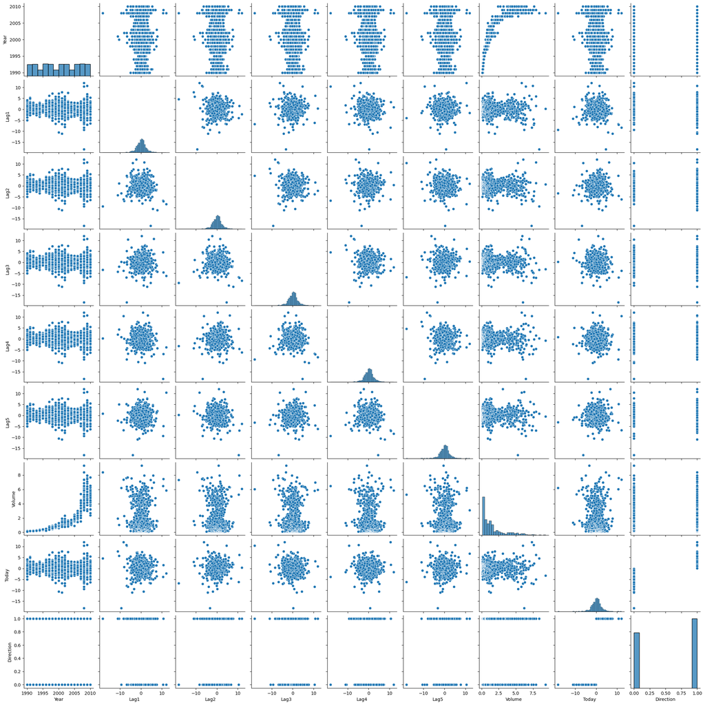

```python
sns.pairplot(data=data_processed)
```

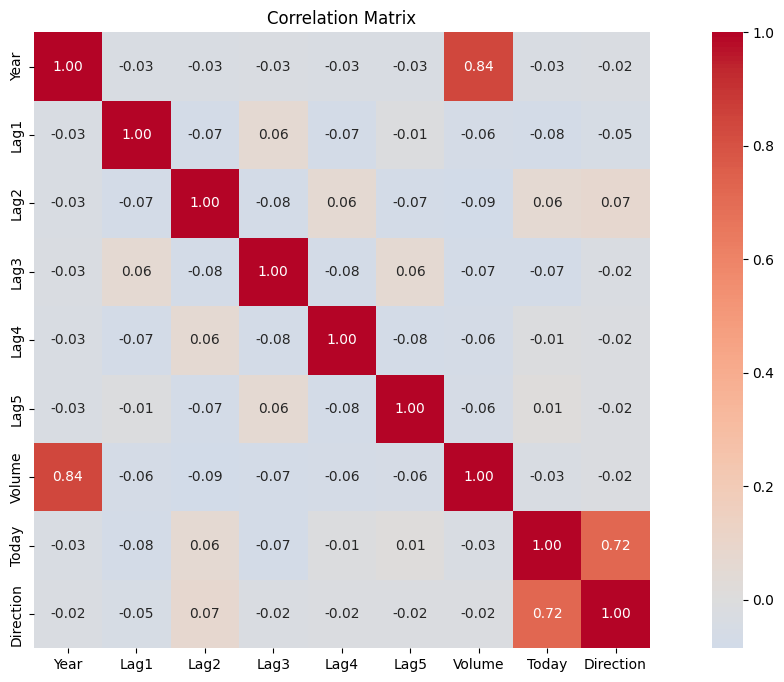

```python
correlation_matrix = data_processed.corr()
plt.figure(figsize=(16, 8))
sns.heatmap(correlation_matrix, annot=True, cmap='coolwarm', fmt='.2f', square=True, center=0.0)
plt.title('Correlation Matrix')
plt.show()
```

- There is a strong correlation between "Volume" and "Year" having value of 0.84 in the data suggesting that the volume of trades has increased over the years.
- There is a strong correlation between "Today" and "Direction" having value of 0.72 in the data. We can see Percentage return for this week (Today) seems to be having positive return on a given week(Direction).
- Other variables seeems to have no correlation or very weak correlation.
- Between Direction and Lag2, there seems to a very weak correlation, but more significant than other Lags. Also we can see Lag2 seems to be correlated to other Lags in a very week manner. (But note that mangnitude is very similar and almost equal)

You can refer to the `seaborn` library documentation to attempt this problem: https://seaborn.pydata.org/

#### b) Use the full data set to perform a logistic regression with Direction as the response and the five `lag` variables plus `Volume` as predictors. Use the summary function to print the results. Do any of the predictors appear to be statistically significant? If so, which ones? Use the statsmodels to construct the classifier.

Link: https://www.statsmodels.org/

```python
import statsmodels.api as sm
Y = data_processed.Direction
X = data_processed[["Lag1","Lag2","Lag3","Lag4","Lag5","Volume"]]
X_train = sm.add_constant(X)
model = sm.Logit(Y, X_train)
result = model.fit()
print(result.summary())
```

```
Optimization terminated successfully.
         Current function value: 0.682441
         Iterations 4
                           Logit Regression Results
==============================================================================
Dep. Variable:              Direction   No. Observations:                 1089
Model:                          Logit   Df Residuals:                     1082
Method:                           MLE   Df Model:                            6
Date:                Wed, 17 Apr 2024   Pseudo R-squ.:                0.006580
Time:                        21:35:52   Log-Likelihood:                -743.18
converged:                       True   LL-Null:                       -748.10
Covariance Type:            nonrobust   LLR p-value:                    0.1313
==============================================================================
                 coef    std err          z      P>|z|      [0.025      0.975]
------------------------------------------------------------------------------
const          0.2669      0.086      3.106      0.002       0.098       0.435
Lag1          -0.0413      0.026     -1.563      0.118      -0.093       0.010
Lag2           0.0584      0.027      2.175      0.030       0.006       0.111
Lag3          -0.0161      0.027     -0.602      0.547      -0.068       0.036
Lag4          -0.0278      0.026     -1.050      0.294      -0.080       0.024
Lag5          -0.0145      0.026     -0.549      0.583      -0.066       0.037
Volume        -0.0227      0.037     -0.616      0.538      -0.095       0.050
==============================================================================
```

- The intercept (const) coefficient is statistically significant (p-value = 0.002), indicating that it's significantly different from zero.
- Among the lag variables, only Lag2 has a statistically significant coefficient (p-value = 0.030), suggesting that Lag2 might be a significant predictor of the direction of market movement.

#### C) Compute the confusion matrix and overall fraction of correct predictions. Explain what the confusion matrix is telling you about the types of mistakes made by logistic regression.

```python
# BEGIN SOLUTION
def metrics_score(actual, predicted, columns):
    cm = confusion_matrix(actual, predicted)
    plt.figure(figsize = (8, 5))
    print("Confusion Matrix:")
    sns.heatmap(cm, annot = True, fmt = '.2f', xticklabels = columns, yticklabels = columns)
    plt.ylabel('Actual')
    plt.xlabel('Predicted')
    plt.show()
    return cm
# END SOLUTION
```

```
Confusion Matrix:
```

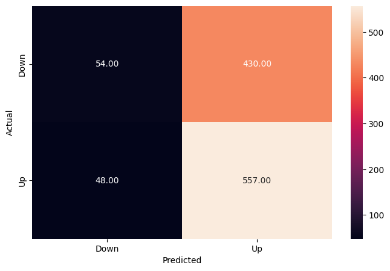

```
              precision    recall  f1-score   support

        Down       0.53      0.11      0.18       484
          Up       0.56      0.92      0.70       605

    accuracy                           0.56      1089
   macro avg       0.55      0.52      0.44      1089
weighted avg       0.55      0.56      0.47      1089
```

```python
# BEGIN SOLUTION
predictions = result.predict(X_train)
predictions_direction = ['Up' if x > 0.5 else 'Down' for x in predictions]
actual_direction = ['Up' if x == 1 else 'Down' for x in Y]
conf_matrix = metrics_score(actual_direction, predictions_direction, ['Down', 'Up'])
print(classification_report(actual_direction, predictions_direction))
# END SOLUTION
```

**Observations:**

- The model shows an accuracy of 56% (That is, Overall fraction of correct prediction is 0.56)
- Overall, the model seems to perform better in predicting the "Up" class compared to the "Down" class, as indicated by the higher precision, recall, and F1-score for the "Up" class. However, the low precision and recall for the "Down" class suggest that the model struggles to correctly predict instances of "Down."
- For the "Up" class, the recall is 0.92, which means that out of all actual "Up" instances, 92% were correctly predicted as "Up". But for "Down" direction, the recall is only 11%

#### d) Now fit the logistic regression model using a training data period from **1990 to 2008**, with `Lag2` as the only predictor. Compute the confusion matrix and the overall fraction of correct predictions for the held out data (that is, the data from **2009 and 2010**).

```python
# BEGIN SOLUTION
train_data = data_processed[(data_processed['Year'] >= 1990) & (data_processed['Year'] <= 2008)]
test_data = data_processed[(data_processed['Year'] >= 2009) & (data_processed['Year'] <= 2010)]
X_train = train_data[['Lag2']]
y_train = train_data['Direction']
X_test = test_data[['Lag2']]
y_test = test_data['Direction']
lg = LogisticRegression()

lg.fit(X_train, y_train)
print("The intercept is ", lg.intercept_)
print("The coefficients are ", lg.coef_)


# END SOLUTION
```

```
The intercept is  [0.20326236]
The coefficients are  [[0.05804742]]
```

```python
# BEGIN SOLUTION
y_pred_train = lg.predict(X_test)
metrics_score(y_test, y_pred_train, ['Down', 'Up'])
# END SOLUTION
```

[output not shown]

```
Confusion Matrix:
```

```
array([[ 9, 34],
       [ 5, 56]])
```

```python
#BEGIN SOLUTION
print(classification_report(y_test, y_pred_train))

#END SOLUTION
```

```
              precision    recall  f1-score   support

           0       0.64      0.21      0.32        43
           1       0.62      0.92      0.74        61

    accuracy                           0.62       104
   macro avg       0.63      0.56      0.53       104
weighted avg       0.63      0.62      0.57       104
```

**Observations:**